# Лабораторна робота №2. Маніпулювання даними

[Костін Є.В.]https://github.com/NickWayne02), 2024

2024-11-04

**Мета:** *Засвоєння принципів, знайомвство з інструментами та набуття навичок манпулювання даними (**wrangle**) засобами мови програмування `R` та колекції пакетів `tidyvers`.*

### Імпорт даних

```r
# install_formats() #інсталяція додаткових компонентів пакету rio

library(rio)
df <- data.frame(x = 1:5, y = rnorm(5))

export(df, "data/df_data_frame.txt")
dfImp <- import("data/df_data_frame.txt")
dfImp
```

|  | x | y |
| --- | --- | --- |
| 1 | 1 | 1.5509146 |
| 2 | 2 | 0.4601128 |
| 3 | 3 | -0.4454119 |
| 4 | 4 | -0.1977613 |
| 5 | 5 | -1.2880579 |

```r
data("mtcars") #підключення стандартного набору даних mtcars
# head(mtcars)
export(head(mtcars), "data/mtcars.dta")
convert('data/mtcars.dta', 'data/mtcars.csv')
import("data/mtcars.csv")
```

|  | mpg | cyl | disp | hp | drat | wt | qsec | vs | am | gear | carb |
| --- | --- | --- | --- | --- | --- | --- | --- | --- | --- | --- | --- |
| 1 | 21.0 | 6 | 160 | 110 | 3.90 | 2.620 | 16.46 | 0 | 1 | 4 | 4 |
| 2 | 21.0 | 6 | 160 | 110 | 3.90 | 2.875 | 17.02 | 0 | 1 | 4 | 4 |
| 3 | 22.8 | 4 | 108 | 93 | 3.85 | 2.320 | 18.61 | 1 | 1 | 4 | 1 |
| 4 | 21.4 | 6 | 258 | 110 | 3.08 | 3.215 | 19.44 | 1 | 0 | 3 | 1 |
| 5 | 18.7 | 8 | 360 | 175 | 3.15 | 3.440 | 17.02 | 0 | 0 | 3 | 2 |
| 6 | 18.1 | 6 | 225 | 105 | 2.76 | 3.460 | 20.22 | 1 | 0 | 3 | 1 |

#### Імпорт з реляційних баз даних

```r
#install.packages("dbplyr")
#install.packages("RSQLite")

library(dbplyr)
library(dplyr)
library(RSQLite)

# my_db <- src_sqlite("data/my_db.sqlite3", create = T)
#head(my_db)
```

```r
#install.packages("nycflights13")
library(nycflights13)
# flights_sqlite <- copy_to(my_db, flights, temporary = FALSE,
#                           indexes = list(c("year", "month", "day"), "carrier", "tailnum"))
# head(flights_sqlite)
```

```r
con <- DBI::dbConnect(RSQLite::SQLite(), path = "data/my_db.sqlite3")
flights_sqlite <- copy_to(con, nycflights13::flights, "flights",
        temporary = FALSE,
        indexes = list(
          c("year", "month", "day"),
          "carrier",
          "tailnum",
          "dest"
        )
)

head(flights_sqlite)
```

| year | month | day | dep_time | sched_dep_time | dep_delay | arr_time | sched_arr_time | arr_delay | carrier | flight | tailnum | origin | dest | air_time | distance | hour | minute | time_hour |
| --- | --- | --- | --- | --- | --- | --- | --- | --- | --- | --- | --- | --- | --- | --- | --- | --- | --- | --- |
| 2013 | 1 | 1 | 517 | 515 | 2 | 830 | 819 | 11 | UA | 1545 | N14228 | EWR | IAH | 227 | 1400 | 5 | 15 | 1357034400 |
| 2013 | 1 | 1 | 533 | 529 | 4 | 850 | 830 | 20 | UA | 1714 | N24211 | LGA | IAH | 227 | 1416 | 5 | 29 | 1357034400 |
| 2013 | 1 | 1 | 542 | 540 | 2 | 923 | 850 | 33 | AA | 1141 | N619AA | JFK | MIA | 160 | 1089 | 5 | 40 | 1357034400 |
| 2013 | 1 | 1 | 544 | 545 | -1 | 1004 | 1022 | -18 | B6 | 725 | N804JB | JFK | BQN | 183 | 1576 | 5 | 45 | 1357034400 |
| 2013 | 1 | 1 | 554 | 600 | -6 | 812 | 837 | -25 | DL | 461 | N668DN | LGA | ATL | 116 | 762 | 6 | 0 | 1357038000 |
| 2013 | 1 | 1 | 554 | 558 | -4 | 740 | 728 | 12 | UA | 1696 | N39463 | EWR | ORD | 150 | 719 | 5 | 58 | 1357034400 |

```r
DBI::dbDisconnect(con)
```

### Приведення даних до охайного вигляду

```r
#install.packages("tidyverse")
library(tidyverse)
```

```r
# відносний критерій на 10000
table1 %>%  # стандартний набір даних
  mutate(rate = cases / population * 10000) # обчислення нового поля
```

| country | year | cases | population | rate |
| --- | --- | --- | --- | --- |
| Afghanistan | 1999 | 745 | 19987071 | 0.372741 |
| Afghanistan | 2000 | 2666 | 20595360 | 1.294466 |
| Brazil | 1999 | 37737 | 172006362 | 2.193930 |
| Brazil | 2000 | 80488 | 174504898 | 4.612363 |
| China | 1999 | 212258 | 1272915272 | 1.667495 |
| China | 2000 | 213766 | 1280428583 | 1.669488 |

```r
# кількість випадків на рік
table1 %>%
  count(year, wt = cases)
```

| year | n |
| --- | --- |
| 1999 | 250740 |
| 2000 | 296920 |

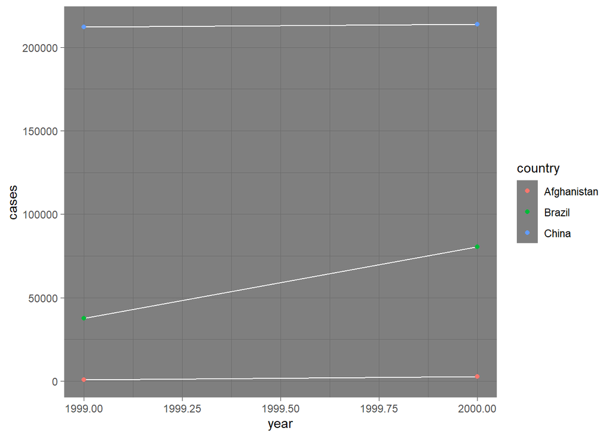

```r
# Візуалізація динаміки зміни кількості випадків з часом
library(ggplot2)

ggplot(table1, aes(year, cases)) +
  geom_line(aes(group = country), colour = "white") +
  geom_point(aes(colour = country))+
  theme_dark()
```

#### Завдання на самостійну роботу.

Побудувати динаміку відносного критерію `rate` кількості захворювань по роках для кожної держави.

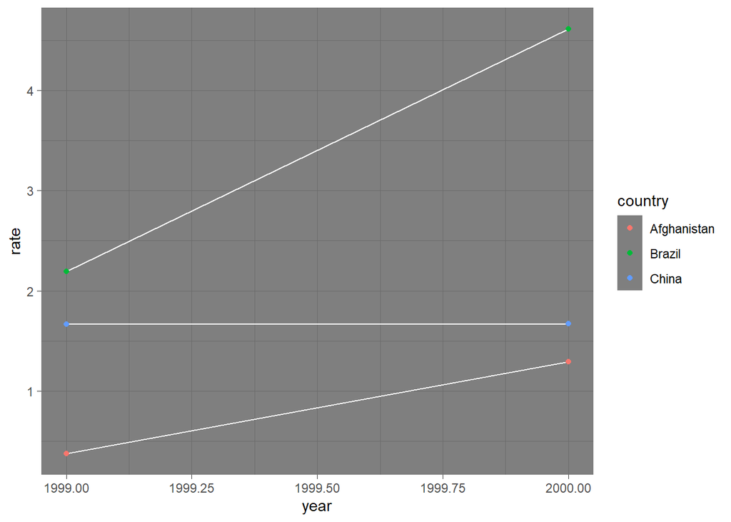

```r
table1 %>%  # стандартний набір даних
  mutate(rate = cases / population * 10000) |>
  ggplot(aes(year, rate)) +
  geom_line(aes(group = country), colour = "white") +
  geom_point(aes(colour = country))+
  theme_dark()
```

### Gathering

```r
table4a
```

| country | 1999 | 2000 |
| --- | --- | --- |
| Afghanistan | 745 | 2666 |
| Brazil | 37737 | 80488 |
| China | 212258 | 213766 |

```r
table4a %>%
  gather(`1999`, `2000`, key = "year", value = "cases")
```

| country | year | cases |
| --- | --- | --- |
| Afghanistan | 1999 | 745 |
| Brazil | 1999 | 37737 |
| China | 1999 | 212258 |
| Afghanistan | 2000 | 2666 |
| Brazil | 2000 | 80488 |
| China | 2000 | 213766 |

```r
tidy4a <- table4a %>%
  gather(`1999`, `2000`, key = "year", value = "cases")
tidy4b <- table4b %>%
  gather(`1999`, `2000`, key = "year", value = "population")
dplyr::left_join(tidy4a, tidy4b)
```

| country | year | cases | population |
| --- | --- | --- | --- |
| Afghanistan | 1999 | 745 | 19987071 |
| Brazil | 1999 | 37737 | 172006362 |
| China | 1999 | 212258 | 1272915272 |
| Afghanistan | 2000 | 2666 | 20595360 |
| Brazil | 2000 | 80488 | 174504898 |
| China | 2000 | 213766 | 1280428583 |

### Завдання на самостійну роботу

Виконати попереднє завдання, базуючись на таблицях `tidy4a` і `tidy4b` з використанням потокового оператора.

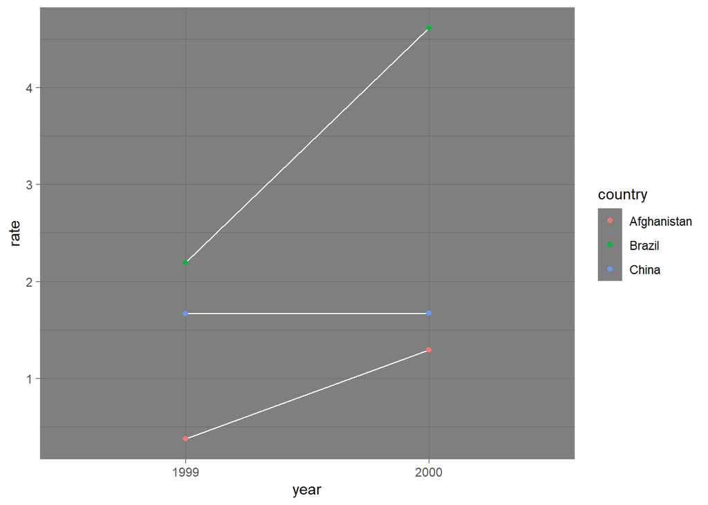

```r
dplyr::left_join(table4a |>
                  gather(`1999`, `2000`, key = "year", value = "cases")
                 ,table4b |>
                   gather(`1999`, `2000`, key = "year", value = "population")) |>
  mutate(rate = cases / population * 10000) |>
  ggplot(aes(year, rate)) +
  geom_line(aes(group = country), colour = "white") +
  geom_point(aes(colour = country))+
  theme_dark()
```

### Spreading

```r
table2
```

| country | year | type | count |
| --- | --- | --- | --- |
| Afghanistan | 1999 | cases | 745 |
| Afghanistan | 1999 | population | 19987071 |
| Afghanistan | 2000 | cases | 2666 |
| Afghanistan | 2000 | population | 20595360 |
| Brazil | 1999 | cases | 37737 |
| Brazil | 1999 | population | 172006362 |
| Brazil | 2000 | cases | 80488 |
| Brazil | 2000 | population | 174504898 |
| China | 1999 | cases | 212258 |
| China | 1999 | population | 1272915272 |

[output cut: 2 more lines]

```r
table2 %>%
    spread(key = type, value = count)
```

| country | year | cases | population |
| --- | --- | --- | --- |
| Afghanistan | 1999 | 745 | 19987071 |
| Afghanistan | 2000 | 2666 | 20595360 |
| Brazil | 1999 | 37737 | 172006362 |
| Brazil | 2000 | 80488 | 174504898 |
| China | 1999 | 212258 | 1272915272 |
| China | 2000 | 213766 | 1280428583 |

### Separating

```r
table3
```

| country | year | rate |
| --- | --- | --- |
| Afghanistan | 1999 | 745/19987071 |
| Afghanistan | 2000 | 2666/20595360 |
| Brazil | 1999 | 37737/172006362 |
| Brazil | 2000 | 80488/174504898 |
| China | 1999 | 212258/1272915272 |
| China | 2000 | 213766/1280428583 |

```r
table3 %>%
  separate(rate, into = c("cases", "population"))
```

| country | year | cases | population |
| --- | --- | --- | --- |
| Afghanistan | 1999 | 745 | 19987071 |
| Afghanistan | 2000 | 2666 | 20595360 |
| Brazil | 1999 | 37737 | 172006362 |
| Brazil | 2000 | 80488 | 174504898 |
| China | 1999 | 212258 | 1272915272 |
| China | 2000 | 213766 | 1280428583 |

### Uniting

```r
table5
```

| country | century | year | rate |
| --- | --- | --- | --- |
| Afghanistan | 19 | 99 | 745/19987071 |
| Afghanistan | 20 | 00 | 2666/20595360 |
| Brazil | 19 | 99 | 37737/172006362 |
| Brazil | 20 | 00 | 80488/174504898 |
| China | 19 | 99 | 212258/1272915272 |
| China | 20 | 00 | 213766/1280428583 |

```r
table5 %>%
  unite(year, century, year, sep = "")
```

| country | year | rate |
| --- | --- | --- |
| Afghanistan | 1999 | 745/19987071 |
| Afghanistan | 2000 | 2666/20595360 |
| Brazil | 1999 | 37737/172006362 |
| Brazil | 2000 | 80488/174504898 |
| China | 1999 | 212258/1272915272 |
| China | 2000 | 213766/1280428583 |

### Пропущені значення

Пропущені значення (**missing value**) у наборах даних можуть бути двох видів: *явні* (позначені як `NA`, `Not Available`) і *неявні* (просто не представлені у даних). Такі дані називаються *некомплектні*.  
Нижче наведено приклад, який це ілюструє.

```r
stocks <- tibble(
  year   = c(2015, 2015, 2015, 2015, 2016, 2016, 2016),
  qtr    = c(   1,    2,    3,    4,    2,    3,    4),
  return = c(1.88, 0.59, 0.35,   NA, 0.92, 0.17, 2.66)
)
stocks
```

| year | qtr | return |
| --- | --- | --- |
| 2015 | 1 | 1.88 |
| 2015 | 2 | 0.59 |
| 2015 | 3 | 0.35 |
| 2015 | 4 | NA |
| 2016 | 2 | 0.92 |
| 2016 | 3 | 0.17 |
| 2016 | 4 | 2.66 |

Дані за четвертий квартал 2015 явно відсутні про що свідчить відповідне значення. Дані за перший квартал не внесені у таблицю, тобто відсутні неявно, але відсутність можна помітити після відповідної траснформації.

```r
stocks %>%
  spread(year, return)
```

| qtr | 2015 | 2016 |
| --- | --- | --- |
| 1 | 1.88 | NA |
| 2 | 0.59 | 0.92 |
| 3 | 0.35 | 0.17 |
| 4 | NA | 2.66 |

Виявити множину некомплектних даних можна також з використанням функції `complete()`.

```r
stocks %>%
  complete(year, qtr)
```

| year | qtr | return |
| --- | --- | --- |
| 2015 | 1 | 1.88 |
| 2015 | 2 | 0.59 |
| 2015 | 3 | 0.35 |
| 2015 | 4 | NA |
| 2016 | 1 | NA |
| 2016 | 2 | 0.92 |
| 2016 | 3 | 0.17 |
| 2016 | 4 | 2.66 |

Проблема некомплектних даних вирішується двома шляхами: виключенням некомплектних спостережень, або імпутацією пропущених значень іншими значеннями, виходячи з певної моделі.

```r
stocks %>%
  spread(year, return) %>%
  gather(year, return, `2015`:`2016`, na.rm = TRUE)
```

| qtr | year | return |
| --- | --- | --- |
| 1 | 2015 | 1.88 |
| 2 | 2015 | 0.59 |
| 3 | 2015 | 0.35 |
| 2 | 2016 | 0.92 |
| 3 | 2016 | 0.17 |
| 4 | 2016 | 2.66 |

У випадках, коли це доцільно, можна використовувати функцію `fill()`, яка заповнює пропущенні значення, взявши значення з останньої заповненої клітинки:

```r
df <- data.frame(Month = 1:12, Year = c(2000, rep(NA, 11)))
df
```

| Month | Year |
| --- | --- |
| 1 | 2000 |
| 2 | NA |
| 3 | NA |
| 4 | NA |
| 5 | NA |
| 6 | NA |
| 7 | NA |
| 8 | NA |
| 9 | NA |
| 10 | NA |

[output cut: 2 more lines]

```r
df %>% fill(Year)
```

| Month | Year |
| --- | --- |
| 1 | 2000 |
| 2 | 2000 |
| 3 | 2000 |
| 4 | 2000 |
| 5 | 2000 |
| 6 | 2000 |
| 7 | 2000 |
| 8 | 2000 |
| 9 | 2000 |
| 10 | 2000 |

[output cut: 2 more lines]

### Трансформація

```r
# Вибірка рядків таблиці
library(dplyr)

starwars %>%
  filter(species == "Droid")
```

| name | height | mass | hair_color | skin_color | eye_color | birth_year | sex | gender | homeworld | species | films | vehicles | starships |
| --- | --- | --- | --- | --- | --- | --- | --- | --- | --- | --- | --- | --- | --- |
| C-3PO | 167 | 75 | NA | gold | yellow | 112 | none | masculine | Tatooine | Droid |  |  |  |
| R2-D2 | 96 | 32 | NA | white, blue | red | 33 | none | masculine | Naboo | Droid |  |  |  |
| R5-D4 | 97 | 32 | NA | white, red | red | NA | none | masculine | Tatooine | Droid |  |  |  |
| IG-88 | 200 | 140 | none | metal | red | 15 | none | masculine | NA | Droid |  |  |  |
| R4-P17 | 96 | NA | none | silver, red | red, blue | NA | none | feminine | NA | Droid |  |  |  |
| BB8 | NA | NA | none | none | black | NA | none | masculine | NA | Droid |  |  |  |

```r
# Вибірка полів таблиці
starwars %>%
  select(name, ends_with("color"))
```

| name | hair_color | skin_color | eye_color |
| --- | --- | --- | --- |
| Luke Skywalker | blond | fair | blue |
| C-3PO | NA | gold | yellow |
| R2-D2 | NA | white, blue | red |
| Darth Vader | none | white | yellow |
| Leia Organa | brown | light | brown |
| Owen Lars | brown, grey | light | blue |
| Beru Whitesun Lars | brown | light | blue |
| R5-D4 | NA | white, red | red |
| Biggs Darklighter | black | light | brown |
| Obi-Wan Kenobi | auburn, white | fair | blue-gray |

[output cut: 77 more lines]

```r
# Створення нового поля у таблиці з послідуючою вибіркою
starwars %>%
  mutate(name, bmi = mass / ((height / 100)  ^ 2)) %>%
  select(name:mass, bmi)
```

| name | height | mass | bmi |
| --- | --- | --- | --- |
| Luke Skywalker | 172 | 77.0 | 26.02758 |
| C-3PO | 167 | 75.0 | 26.89232 |
| R2-D2 | 96 | 32.0 | 34.72222 |
| Darth Vader | 202 | 136.0 | 33.33007 |
| Leia Organa | 150 | 49.0 | 21.77778 |
| Owen Lars | 178 | 120.0 | 37.87401 |
| Beru Whitesun Lars | 165 | 75.0 | 27.54821 |
| R5-D4 | 97 | 32.0 | 34.00999 |
| Biggs Darklighter | 183 | 84.0 | 25.08286 |
| Obi-Wan Kenobi | 182 | 77.0 | 23.24598 |

[output cut: 77 more lines]

```r
# Сортування даних
starwars %>%
  arrange(desc(mass))
```

| name | height | mass | hair_color | skin_color | eye_color | birth_year | sex | gender | homeworld | species | films | vehicles | starships |
| --- | --- | --- | --- | --- | --- | --- | --- | --- | --- | --- | --- | --- | --- |
| Jabba Desilijic Tiure | 175 | 1358.0 | NA | green-tan, brown | orange | 600.0 | hermaphroditic | masculine | Nal Hutta | Hutt |  |  |  |
| Grievous | 216 | 159.0 | none | brown, white | green, yellow | NA | male | masculine | Kalee | Kaleesh |  |  |  |
| IG-88 | 200 | 140.0 | none | metal | red | 15.0 | none | masculine | NA | Droid |  |  |  |
| Darth Vader | 202 | 136.0 | none | white | yellow | 41.9 | male | masculine | Tatooine | Human |  |  |  |
| Tarfful | 234 | 136.0 | brown | brown | blue | NA | male | masculine | Kashyyyk | Wookiee |  |  |  |
| Owen Lars | 178 | 120.0 | brown, grey | light | blue | 52.0 | male | masculine | Tatooine | Human |  |  |  |
| Bossk | 190 | 113.0 | none | green | red | 53.0 | male | masculine | Trandosha | Trandoshan |  |  |  |
| Chewbacca | 228 | 112.0 | brown | unknown | blue | 200.0 | male | masculine | Kashyyyk | Wookiee |  |  |  |
| Jek Tono Porkins | 180 | 110.0 | brown | fair | blue | NA | NA | NA | Bestine IV | NA |  |  |  |
| Dexter Jettster | 198 | 102.0 | none | brown | yellow | NA | male | masculine | Ojom | Besalisk |  |  |  |

[output cut: 77 more lines]

```r
# Обчислення агрегатів з попереднім групуванням по полю species
starwars %>%
  group_by(species) %>%
  summarise(
    n = n(),
    mass = mean(mass, na.rm = TRUE)
  ) %>%
  filter(n > 1)
```

| species | n | mass |
| --- | --- | --- |
| Droid | 6 | 69.75 |
| Gungan | 3 | 74.00 |
| Human | 35 | 81.31 |
| Kaminoan | 2 | 88.00 |
| Mirialan | 2 | 53.10 |
| Twi'lek | 2 | 55.00 |
| Wookiee | 2 | 124.00 |
| Zabrak | 2 | 80.00 |
| NA | 4 | 81.00 |

## Індивідуальне завдання

```r
library(shiny)
library(plotly)
library(readxl)
library(httr)
library(dplyr)
library(lubridate)
library(DT)
# Функція для завантаження даних з файлу .xls
load_data_from_file <- function(file_path) {
  df <- read_excel(file_path)

  if (!"Дата" %in% colnames(df)) {
    stop("Файл не містить стовпця 'Дата'. Переконайтеся, що файл має правильний формат.")
  }

  df$Дата <- as.Date(df$Дата, format = "%d.%m.%Y")

  if (nrow(df) == 0) {
    stop("Файл не містить даних. Перевірте вміст файлу.")
  }

  return(df)
}

# Завантаження даних з файлу
file_path <- "data/currency_data.xlsx"
currency_data <- load_data_from_file(file_path)

# Функція для завантаження даних з API НБУ
load_data_from_nbu <- function(currency_code, start_date, end_date) {
  start_date_formatted <- format(start_date, "%Y%m%d")
  end_date_formatted <- format(end_date, "%Y%m%d")

  url <- paste0("https://bank.gov.ua/NBUStatService/v1/statdirectory/exchange?valcode=", currency_code, "&date=", start_date_formatted, "&json")
  response <- content(GET(url), "parsed")

  df <- data.frame(
    Дата = as.Date(sapply(response, function(x) x$exchangedate), format="%d.%m.%Y"),
    rate = sapply(response, function(x) x$rate),
    currency = currency_code
  )

  return(df)
}

# Обробка даних для щоденних та середньомісячних курсів
process_data <- function(df) {
  df_daily <- df %>% arrange(Дата)
  df_monthly <- df %>%
    group_by(month = floor_date(Дата, "month"), currency) %>%
    summarize(rate = mean(rate, na.rm = TRUE), .groups = 'drop')

  return(list(daily = df_daily, monthly = df_monthly))
}

# Інтерфейс Shiny
ui <- fluidPage(
  titlePanel("Моніторинг курсу валют"),
  sidebarLayout(
    sidebarPanel(
      checkboxGroupInput("currencies", "Оберіть валюти:",
                         choices = c("USD", "EUR", "RUB"), selected = c("USD", "EUR", "RUB"))
    ),
    mainPanel(
      plotlyOutput("currencyPlot"),
      DTOutput("currencyTable")
    )
  )
)

# Сервер Shiny
server <- function(input, output) {
  data <- reactive({
    selected_currencies <- input$currencies
    all_data <- lapply(selected_currencies, function(currency) {
      load_data_from_nbu(currency, as.Date("2024-01-01"), Sys.Date())
    })

    nbu_data <- bind_rows(all_data)
    combined_data <- bind_rows(currency_data, nbu_data)
    processed_data <- process_data(combined_data)

    return(processed_data)
  })

  output$currencyPlot <- renderPlotly({
    df <- data()
    if (nrow(df$daily) == 0 || nrow(df$monthly) == 0) {
      return(NULL)
    }

    fig <- plot_ly()
    for (currency in unique(df$daily$currency)) {
      fig <- fig %>%
        add_lines(data = df$daily %>% filter(currency == currency), x = ~Дата, y = ~rate, name = paste("Щоденний курс", currency)) %>%
        add_lines(data = df$monthly %>% filter(currency == currency), x = ~month, y = ~rate, name = paste("Середньомісячний курс", currency), line = list(dash = 'dash'))
    }

    fig <- fig %>% layout(title = "Курс валют до гривні",
                          xaxis = list(title = "Дата"),
                          yaxis = list(title = "Курс"),
                          hovermode = "x unified",  # Додаємо уніфікований режим наведення
                          legend = list(orientation = "h", x = 0.5, xanchor = "center"))  # Переміщуємо легенду внизу графіку
    fig
  })

  output$currencyTable <- renderDT({
    datatable(data()$daily, options = list(pageLength = 10), rownames = FALSE)
  })
}

# Запуск додатку Shiny
shinyApp(ui = ui, server = server)
```

Shiny applications not supported in static R Markdown documents